# Jake Bailey, Part 2

More Puntalytics with Jake Bailey

In part 2 of our interview with Jake Bailey, we ask the all-pro to elaborate on his approach and how he evaluates his performance.

*The Punt Runts: How many different punt plays does the team have? To what extent are you being directed on the sidelines what to do in a particular situation?*

**Jake Bailey:** There are a few different “golf swings” you have in a punt where you want to accomplish a few different things like when you walk out there and it’s all dependent on the conditions that present themselves in front of you.

Because when you’re at Gillette punting towards the lighthouse, that creates a huge wind swirl, so the wind comes in through there and then sometimes it’ll go to the right and sometimes it blows hard to the left.

So all of your warm-ups you’re trying to get a gauge on where the wind is on three different levels: the field level, the medium level, and then the high level. The majority of the time where the punt can go wrong is the field level or the middle level. Once your punt gets all the way up to the top, it’s going where it’s going. But mis-hits occur, where the ball gets screwed up from the wind. So that’s what I’m doing in warm-ups…trying to figure out where the wind is, how to hit all my different types of punts.

Those different types of punts would be:

1. punt right,
2. punt left,
3. your normal get-as-much-hang-time-as-much-distance-and-as-accurate-as-possible punt,
4. a little opposite punt, where you aim right to show the returner you’re going to hit it to the right and drop the ball inside nose down and yank it around to your left. I hit that twice against Tyreek Hill and Mecole Hardman against the Chiefs and that worked really well because the wind pattern going that way carried the ball to the sideline. I remember those punts were nice, they didn’t have the best hang time but it doesn’t matter if you’re hitting it out of bounds or on the sideline. Justin Bethel and Matt Slater are going to be there.

Those are the punts types that I have, and you could do

5. the little banana punt. I hit that in the Dolphins game at the end of the season. I got a spoon right here. So pretend it’s a football. If this is how you normally drop it [demonstrating a drop with the football parallel to the swinging foot]. If you want to spiral it going this way, I dropped the nose this way [demonstrating a drop with the football perpendicular to the swinging foot] and kind of hit the end of the ball over here and it kind of does like a boomerang little thing. It’s really hard for the returners to catch it. That’s a pin-it inside-the-10-and-maybe-try-and-manufacturer-a-muffed-punt.

And then obviously you do the

6. inside the five, end over end, and have Matt Slater go catch it there. That’s about it. I’ve experimented with the laser punt with no hang time, spiral punt, just on the sideline, but that’s pretty hard to perfect and especially with different wind patterns in Gillette, it’s hard to do that one.

*The Punt Runts: In our processing of plays we pick the own 40 as the boundary between open-field and pin-deep. How well does that yard line align with what’s going through your head?*

**Jake Bailey:** You guys are good, so anything beyond the 40, if the wind is not a variable and temperature is not a variable. I would say I start changing my punt techniques right around the 42 yard line. If you have wind at your back, I think the 35 yard line sometimes I’ll start to kick it down a little bit. But again, if you hit a touchback and the line of scrimmage is about the 40, it’s still a 40 yard punt, and so there’s like a lot of potential for reward, with the risk of not being that bad. So when the ball is kind of in between the 35 and 40 I go hunt for the goal line and try to get the ball pretty far down there because, even if you hit a touchback you’re not that mad about it. And then, once you get like 45 to the 50 yard line that’s when you kind of get a little bit more conservative and then anything like in front of the 50 yard line you’re just trying to get it inside the 10 and not hit a touchback. So the 40 yard line is a pretty good indicator that I would say.

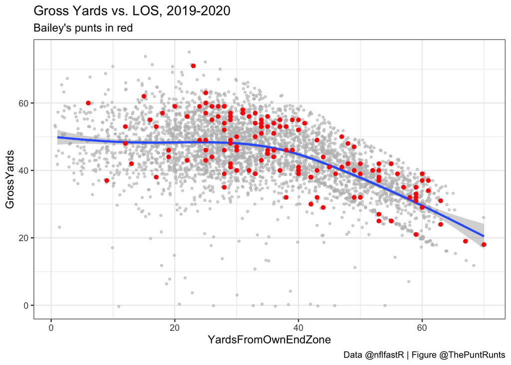

*This plot of Gross Yards vs. LOS (a favorite of us at Puntalytics) shows that, as Jake says, the average Gross Yards / punt starts to “respond” to the field position right around the punter’s 35-40 yard line.*

*The Punt Runts: When you’re walking off the field after a play, what sort of numbers are in your head to judge whether you just did a good job?*

**Jake Bailey:** Each person is different and each field position is different. I can’t be mad that I didn’t hit a 55 yard net punt when the ball is on the plus 40 so it’s just all about what situation presents itself in front of you. I’d be lying if I wasn’t mindful of my average during the game. I would like to walk away with around a 45 yard net average after a game. You can’t control that all the time, sometimes you have six punts and all of them are short punts that you try and pin the ball inside the 10, you don’t really have an open field to go for but if you can walk away from a punt after the play’s done and be like “okay I I maximized my net yardage right there,” I’d feel good about it.

*The Punt Runts: One of our big things is trying to exonerate punters for longer returns. How do you feel about that?*

**Jake Bailey:** I don’t know how I feel about that. I hold myself to a pretty high standard and I don’t let the coverage team ever be an excuse. I know if I hit my perfect punt the ball is not going to be returned and a 45 yard+ net. Anything beyond that is my fault, I gotta take that as that. The coverage team is just there to make sure if I mess up, they can make sure the damage is not too bad.

*The Punt Runts: If I’m remembering correctly, the data says that your return percentage is super low, we can go check. (brief pause) Yep, you had the lowest return percentage in the league last year.*

|  | punter_player_name | returnpct | Gross | Net | Punter_EPA |
| --- | --- | --- | --- | --- | --- |
| 1 | J.Bailey | 0.22 | 46.87 | 45.58 | 0.34 |
| 2 | T.Townsend | 0.29 | 42.63 | 40.29 | -0.01 |
| 3 | A.Cole | 0.32 | 43.16 | 40.14 | 0.04 |
| 4 | T.Morstead | 0.32 | 42.48 | 41.74 | -0.09 |
| 5 | S.Koch | 0.33 | 44.08 | 42.47 | 0.02 |
| 6 | J.Hekker | 0.35 | 43.46 | 39.16 | 0.04 |
| 7 | B.Kern | 0.35 | 44.19 | 41.49 | 0.16 |
| 8 | B.Anger | 0.35 | 44.17 | 41.8 | 0 |
| 9 | M.Haack | 0.35 | 44.12 | 39.75 | 0.02 |
| 10 | J.Fox | 0.36 | 46.73 | 44.76 | 0.2 |

[output cut: 21 more lines]

*Interestingly, return percentage doesn’t correlate super well with other metrics like Net and EPA/punt; that said, Jake Bailey led the league in all three last season.*

**Jake Bailey:** That’s 100% due to Matt Slater and Justin Bethel being that fast and just making sure, like the returners are scared to pick up the ball, scared to return it. As well as [Long Snapper Joe Cardona] having such a fast snap allowing me to take time. So teams don’t want to rush us all that much, and I can still take my time, sit back there and know that I’m not totally going to be rushed but go a little bit fast. The whole punt team works together in such unison, where if Joe does his job, that allows me to do my job, and that allows Matt and Justin to do their jobs and it works out really well.

*The Punt Runts: How many data points do you have about each play, that someone is either keeping track of for this time from a stopwatch or you have player tracking data available for?*

**Jake Bailey:** There’s our player operations guy, one of my good friends, his name’s Chris. I give him a stopwatch and I tell him, “this is what you want to chart,” really just my off time. I make sure I’m conscious of that, because that’s probably the lowest margin for error. When I catch the ball and I’m a little bit slower and I don’t realize it, that’s where stuff can go wrong, because the other team is mindful of that too. They clock me in and they’re like “oh he’s 2.1 [seconds from snap to punt] on that one, let’s rush him the next play. So I ask him [Chris] to be mindful of that, so I can be mindful of it, so the other team doesn’t rush me. The iPads that we have track your net distance, so I’ll look at that after the play, but other than that, you know what a good punt looks like. If I hit one, I see the result being good, I’m happy with it, and I kind of just go focus on the next one.

*The Punt Runts: So is a longer off time the primary cause of a blocked punt, or are there other factors that contribute to blocked punts?*

**Jake Bailey:** There are definitely other factors, but I think if you have an off time under 1.9 seconds, which I don’t always have, you’re good. So that’s like from when Joe moves his fingers to me hitting it with my foot, that would be 1.9 seconds, and I would say, even if a guard completely lets a guy through, the ball is almost going to get off. So if the guy on the line can just get in a guy’s way and I’m at my most efficient and Joe is too, balls can get off most of the time. It’s not going to be the best punt all the time, because you’re a little rushed. The off time is a factor, the line is a factor. That’s why punts are my favorite play on the football field, because it is truly like every single person does their job. It’s not like the quarterback is going to put a team on his back right now. If Joe doesn’t do his job I can’t do my job, and if then I can’t do my job, Justin and Matt can’t do theirs, and the rest of the team, etc… so everybody helps everybody out.

*The Punt Runts: Do you have a favorite part of your career or favorite moment? How well do you remember those?*

**Jake Bailey:** Those are so funny because like, I just remember the bad ones… It’s so bad. I can tell you right now what was going through my head that last game of the season.

I had my worst punt of the season, we were on the [opposing] 43 yard and I hit a touchback and it ended up grading out as a 23 yard or 20 yard punt. I hated that one.

*The Punt Runts: I remember, we were following that because that was the part of the season that we thought, “Jake Bailey might grade out as our best punter season ever.” And I was following that game on ESPN and I remember texting the guys, being like “Jake Bailey just hit a touchback from the 40, it’s not good for his record.”*

**Jake Bailey:** We all had the same reaction on the sideline.

Best part, though: I don’t remember which punt it was, but when we played the Texans, at one point we were trying to adjust the direction of the punt. And I ended up hitting it right, and it was probably one of my best hang times of the season. It went right on the sideline and if it had been two inches closer to the sideline the returner would have caught out of bounds. *(You can see that punt [here](https://www.youtube.com/embed/BSk70wHmo0M?start=377), if you’re curious).*

For more content like this, be sure to follow @ThePuntRunts on Twitter!  
[Follow @ThePuntRunts](https://twitter.com/ThePuntRunts?ref_src=twsrc%5Etfw)